# 201.4. DiaObject table

For the Rubin Science Platform at data.lsst.cloud.  
Data Release: [Data Preview 2](https://dp2.lsst.io/)  
Container Size: Large  
LSST Science Pipelines version: r30.0.10  
Last verified to run: 2026-07-22  
Repository: github.com/lsst/tutorial-notebooks  
DOI: 10.11578/rubin/dc.20250909.20

**Learning objective:** To understand the contents of the `DiaObject` table and how to access it.

**LSST data products:** `DiaObject`

**Packages:** `lsst.rsp`, `lsst.daf.butler`

**Credit:** Originally developed by the Rubin Community Science team with feedback from Eric Bellm. Please consider acknowledging them if this notebook is used for the preparation of journal articles, software releases, or other notebooks.

**Get Support:** Everyone is encouraged to ask questions or raise issues in the [Support Category](https://community.lsst.org/c/support) of the Rubin Community Forum. Rubin staff will respond to all questions posted there.

## 1. Introduction

The `DiaObject` table contains $ugrizy$ light curve summary statistics for static-sky time-varying astronomical objects. These light curve summary statistics (e.g., mean, standard deviation in the flux measurements) are primarily derived from the difference-image flux measurements, and only for visits for which the object was detected at $>5\sigma$ in the difference image (i.e., not from forced photometry; from the `DiaSource` table, not from `ForcedSourceOnDiaObject` table). Difference-image detections (called "diaSources" and stored in the `DiaSource` table) are associated into "diaObjects" using a 1-arcsecond radius.

- TAP table name: `dp2.DiaObject`
- butler table name: `dia_object`
- columns: 64
- rows: 232,004,216

**Related tutorials:** The TAP and butler data access services are demonstrated in the 100-level "How to" tutorials. There are a 200-level tutorials on the difference images and the `DiaSource` and `ForcedSourceOnDiaObject` tables.

### 1.1. Import packages

Import standard python packages `numpy`, `matplotlib`, and `astropy`.

From the `lsst` package, import modules for the TAP service and the butler.

```python
import re
import numpy as np
import matplotlib.pyplot as plt
from lsst.rsp import RSPDiscovery
from lsst.daf.butler import Butler
```

### 1.2. Define parameters and functions

Create an instance of the TAP service, and assert that it exists.

```python
discovery = RSPDiscovery("dp2")
tap_service = discovery.get_tap_client()
```

Create an instance of the Rubin data butler, and assert that it exists.

```python
butler = Butler("dp2", collections="dp2")
```

## 2. Schema (columns)

To browse the table schema visit the [Rubin schema browser](https://sdm-schemas.lsst.io/), or use the TAP service via the Portal Aspect or as demonstrated in Section 2.1.

### 2.1. Retrieve table schema

To retrieve the table schema, define a query for the schema columns of the `DiaObject` table and run the query job.

```python
query = "SELECT column_name, datatype, description, unit " \
        "FROM tap_schema.columns " \
        "WHERE table_name = 'dp2.DiaObject'"
job = tap_service.submit_job(query)
job.run()
job.wait(phases=['COMPLETED', 'ERROR'])
print('Job phase is', job.phase)
if job.phase == 'ERROR':
    job.raise_if_error()
assert job.phase == 'COMPLETED'
```

```
Job phase is COMPLETED
```

Retrieve the query results and display them as an `astropy` table with the `to_table()` attribute.

```python
results = job.fetch_result().to_table()
results
```

*Table length=64*

| column_name str64 | datatype str64 | description str512 | unit str64 |
| --- | --- | --- | --- |
| diaObjectId | long | Unique identifier of this DiaObject. |  |
| ra | double | Right Ascension coordinate of the position of the DiaObject. | deg |
| dec | double | Declination coordinate of the position of the DiaObject. | deg |
| u_psfFluxMean | double | Weighted mean point-source model magnitude for u filter. | nJy |
| u_psfFluxMeanErr | double | Standard error of u_psfFluxMean. | nJy |
| u_psfFluxSigma | double | Standard deviation of the distribution of u_psfFlux. | nJy |
| u_psfFluxNdata | int | The number of u-band data points. |  |
| g_psfFluxMean | double | Weighted mean point-source model magnitude for g filter. | nJy |
| g_psfFluxMeanErr | double | Standard error of g_psfFluxMean. | nJy |
| g_psfFluxSigma | double | Standard deviation of the distribution of g_psfFlux. | nJy |
| g_psfFluxNdata | int | The number of g-band data points. |  |
| r_psfFluxMean | double | Weighted mean point-source model magnitude for r filter. | nJy |
| r_psfFluxMeanErr | double | Standard error of r_psfFluxMean. | nJy |
| r_psfFluxSigma | double | Standard deviation of the distribution of r_psfFlux. | nJy |
| r_psfFluxNdata | int | The number of r-band data points. |  |
| i_psfFluxMean | double | Weighted mean point-source model magnitude for i filter. | nJy |
| i_psfFluxMeanErr | double | Standard error of i_psfFluxMean. | nJy |
| i_psfFluxSigma | double | Standard deviation of the distribution of i_psfFlux. | nJy |
| i_psfFluxNdata | int | The number of i-band data points. |  |
| z_psfFluxMean | double | Weighted mean point-source model magnitude for z filter. | nJy |
| z_psfFluxMeanErr | double | Standard error of z_psfFluxMean. | nJy |
| z_psfFluxSigma | double | Standard deviation of the distribution of z_psfFlux. | nJy |
| ... | ... | ... | ... |
| u_psfFluxErrMean | float | Mean of the u band flux errors. | nJy |
| g_psfFluxMin | double | Minimum observed g band fluxes. | nJy |
| g_psfFluxMax | double | Maximum observed g band fluxes. | nJy |
| g_psfFluxMaxSlope | double | Maximum slope between g band flux obsevations max(delta_flux/delta_time). | nJy/d |
| g_psfFluxErrMean | float | Mean of the g band flux errors. | nJy |
| r_psfFluxMin | double | Minimum observed r band fluxes. | nJy |
| r_psfFluxMax | double | Maximum observed r band fluxes. | nJy |
| r_psfFluxMaxSlope | double | Maximum slope between r band flux obsevations max(delta_flux/delta_time). | nJy/d |
| r_psfFluxErrMean | float | Mean of the r band flux errors. | nJy |
| i_psfFluxMin | double | Minimum observed i band fluxes. | nJy |
| i_psfFluxMax | double | Maximum observed i band fluxes. | nJy |
| i_psfFluxMaxSlope | double | Maximum slope between i band flux obsevations max(delta_flux/delta_time). | nJy/d |
| i_psfFluxErrMean | float | Mean of the i band flux errors. | nJy |
| z_psfFluxMin | double | Minimum observed z band fluxes. | nJy |
| z_psfFluxMax | double | Maximum observed z band fluxes. | nJy |
| z_psfFluxMaxSlope | double | Maximum slope between z band flux obsevations max(delta_flux/delta_time). | nJy/d |
| z_psfFluxErrMean | float | Mean of the z band flux errors. | nJy |
| y_psfFluxMin | double | Minimum observed y band fluxes. | nJy |
| y_psfFluxMax | double | Maximum observed y band fluxes. | nJy |
| y_psfFluxMaxSlope | double | Maximum slope between y band flux obsevations max(delta_flux/delta_time). | nJy/d |
| y_psfFluxErrMean | float | Mean of the y band flux errors. | nJy |
| nDiaSources | long | Total number of DiaSources associated with this DiaObject. |  |

The table displayed above has been truncated.

Option to print every column name as a list.

```python
# for col in results['column_name']:
#    print(col)
```

Option to use the regular expressions package `re` to find all column names that hold the `psfFluxMean` for the six filters.

```python
# for col in results['column_name']:
#     if re.fullmatch('[ugrizy]_psfFluxMean', col):
#         print(col)
```

Option to search column names that contain the string defined as `temp`.

```python
# temp = 'Max'
# temp = 'Slope'
# temp = 'psfFluxMean'
# for col in results['column_name']:
#     if re.search(temp, col):
#         print(col)
```

Delete the job, but not the `results`.

```python
del query
job.delete()
```

### 2.2. Column descriptions

There are few columns in the `DiaObject` table, and all are described below.

#### 2.2.1. Identifier

The long integer that uniquely identifies each row of the `DiaObject` table.

- `diaObjectId`

#### 2.2.2. Coordinates

The sky coordinates in decimal degrees for each `diaObject`.

- `ra`
- `dec`

#### 2.2.3. Number of detections

Total number of detections across all filters (i.e., number of associated `diaSource`s.

- `nDiaSources`

#### 2.2.4. Flux statistics

A limited number of flux statistics are calculated for DP2, and they are calculated from the $>5\sigma$ detections in the `DiaSource` table (not from the forced photometry). Fluxes are used for difference-image photometry (not magnitudes) because difference-images fluxes can be negative.

Several types of statistics on the Point Spread Function (PSF) fluxes measured on the difference image detections in the `DiaSource` table are calculated for diaObjects, as follows.

- `[f]_psfFluxMean`, `[f]_psfFluxMeanErr`: Weighted mean of PSF flux in band [f], and error on the mean.
- `[f]_psfFluxSigma`: Standard deviation of the distribution of [f]_psfFlux values.
- `[f]_psfFluxErrMean`: Mean of the flux errors.
- `[f]_psfFluxMax` and `Min`: Maximum and minimum PSF flux.
- `[f]_psfFluxMaxSlope`: Maximum slope between any two sequential [f]-band observations.
- `[f]_psfFluxNdata`: Number of [f]-band data points (from the `DiaSource` table; number of [f]-band detections).

Average fluxes based on PSF photometry on the visit images (i.e., the "direct" or "science" image) at the position of the detected diaSources associated with a diaObject are also provided (`[f]_scienceFluxMean`). Use caution with all science-image fluxes for time-varying objects as there may be contamination from static sources (e.g., host galaxies).

### 2.3. Descriptions and units

For a subset of the key columns show the table of their descriptions and units.

```python
col_list = set(['diaObjectId', 'ra', 'dec', 'nDiaSources',
                'r_psfFluxMean', 'r_psfFluxMeanErr', 'r_psfFluxSigma', 'r_psfFluxErrMean',
                'r_psfFluxMax', 'r_psfFluxMin', 'r_psfFluxMaxSlope', 'r_psfFluxNdata'])
tx = [i for i, item in enumerate(results['column_name']) if item in col_list]
results[tx]
```

*Table length=12*

| column_name str64 | datatype str64 | description str512 | unit str64 |
| --- | --- | --- | --- |
| diaObjectId | long | Unique identifier of this DiaObject. |  |
| ra | double | Right Ascension coordinate of the position of the DiaObject. | deg |
| dec | double | Declination coordinate of the position of the DiaObject. | deg |
| r_psfFluxMean | double | Weighted mean point-source model magnitude for r filter. | nJy |
| r_psfFluxMeanErr | double | Standard error of r_psfFluxMean. | nJy |
| r_psfFluxSigma | double | Standard deviation of the distribution of r_psfFlux. | nJy |
| r_psfFluxNdata | int | The number of r-band data points. |  |
| r_psfFluxMin | double | Minimum observed r band fluxes. | nJy |
| r_psfFluxMax | double | Maximum observed r band fluxes. | nJy |
| r_psfFluxMaxSlope | double | Maximum slope between r band flux obsevations max(delta_flux/delta_time). | nJy/d |
| r_psfFluxErrMean | float | Mean of the r band flux errors. | nJy |
| nDiaSources | long | Total number of DiaSources associated with this DiaObject. |  |

Clean up.

```python
del col_list, tx, results
```

## 3. Data access

The `DiaObject` table is available via the TAP service and the butler.

**Recommended access method:** TAP.

### 3.1. Advisory: avoid full-table queries

**Avoid full-table queries. Always include spatial constraints.**

Skipping spatial constraints is not a good habit to form, because future data release `DiaObject` tables will contain billions of rows.

### 3.2. TAP (Table Access Protocol)

The `DiaObject` table is stored in Qserv and accessible via the TAP services using ADQL queries.

**Include spatial constraints:** Qserv stores catalog data sharded by coordinate (RA, Dec), so ADQL query statements that include constraints by coordinate do not requre a whole-catalog search and are typically faster (and can be much faster) than ADQL query statements which only include constraints for other columns. Use either an ADQL cone or polygon search for faster queries (do not use `WHERE ... BETWEEN` statements to set boundaries on RA and Dec).

#### 3.2.1. Demo query

Define a query to return, as an example, $r$-band flux statistics and other key columns for a sample from the `DiaObject` table.

Impose **spatial constraints**: search within 0.2 degrees of the center of Extended Chandra Deep Field South (ECDFS), RA, Dec = $53.13, -28.10$. (This is not a special region, just used as an example.) Also impose the constraint that a diaObject must be detected more than 5 times in the $r$-band to be returned.

```python
query = """SELECT diaObjectId, ra, dec, nDiaSources,
           r_psfFluxMean, r_psfFluxMeanErr, r_psfFluxSigma, r_psfFluxErrMean
           r_psfFluxMax, r_psfFluxMin, r_psfFluxMaxSlope, r_psfFluxNdata
           FROM dp2.DiaObject
           WHERE CONTAINS(POINT('ICRS', ra, dec), CIRCLE('ICRS', 53.13, -28.10, 0.2)) = 1
           AND r_psfFluxNdata > 5"""
```

```python
job = tap_service.submit_job(query)
job.run()
job.wait(phases=['COMPLETED', 'ERROR'])
print('Job phase is', job.phase)
if job.phase == 'ERROR':
    job.raise_if_error()
```

```
Job phase is COMPLETED
```

Fetch the results as an `astropy` table.

```python
assert job.phase == 'COMPLETED'
results = job.fetch_result().to_table()
print(len(results))
```

```
143
```

Option to display the table.

```python
results
```

*Table length=143*

| diaObjectId int64 | ra deg float64 | dec deg float64 | nDiaSources int64 | r_psfFluxMean nJy float64 | r_psfFluxMeanErr nJy float64 | r_psfFluxSigma nJy float64 | r_psfFluxMax nJy float32 | r_psfFluxMin nJy float64 | r_psfFluxMaxSlope nJy / d float64 | r_psfFluxNdata int32 |
| --- | --- | --- | --- | --- | --- | --- | --- | --- | --- | --- |
| 753904749157285963 | 53.14832869656018 | -28.269922609388026 | 65 | 1452.173095703125 | 90.1224136352539 | 2293.283203125 | 399.116 | -4651.71630859375 | 7349594.0546763055 | 15 |
| 755369504803913742 | 53.317067913368284 | -28.065950468747108 | 50 | 1347.314697265625 | 96.15044403076172 | 895.3720703125 | 344.23 | -392.6014099121094 | 5672649.624738062 | 12 |
| 755369504803913739 | 53.33693488938166 | -28.177236196683403 | 82 | -1086.5665283203125 | 226.78231811523438 | 2771.3349609375 | 600.068 | -5173.630859375 | 672289.1952654346 | 6 |
| 755369504803913736 | 53.278304420554484 | -28.153992727748907 | 68 | 792.35302734375 | 53.17058563232422 | 2240.653076171875 | 220.214 | -1986.34228515625 | 714026.389804091 | 16 |
| 755369504803913829 | 53.32501128602706 | -28.119075044574025 | 41 | 81.85987091064453 | 74.57477569580078 | 1235.632568359375 | 250.089 | -1603.5677490234375 | 2738816.39066981 | 11 |
| 755369504803913773 | 53.29169666040039 | -28.147946939339093 | 47 | 2660.990478515625 | 149.6099090576172 | 1558.83203125 | 505.097 | 510.4138488769531 | 160.2960186757777 | 10 |
| 755369504803913779 | 53.33076218263827 | -28.11934205117699 | 90 | 11265.4365234375 | 228.516845703125 | 3788.96337890625 | 1066.3 | 5264.23193359375 | 11995031.701225795 | 19 |
| 755369504803913766 | 53.35594282265226 | -28.092876695563337 | 47 | 34017.62109375 | 375.82025146484375 | 8091.06591796875 | 1546.95 | 21943.568359375 | 41806365.64615777 | 15 |
| 755369504803913788 | 53.28594620840545 | -28.16034732567813 | 90 | 3134.499755859375 | 151.6095733642578 | 2816.849365234375 | 490.329 | -128.31414794921875 | 1025336.091491876 | 9 |
| 755369504803913795 | 53.345871637348694 | -28.06365082391602 | 64 | -707.553955078125 | 134.01622009277344 | 1970.005859375 | 339.339 | -2759.22314453125 | 9794073.172698513 | 6 |
| 755369504803913790 | 53.28928332887084 | -28.123854674330964 | 74 | -5756.42529296875 | 281.1304626464844 | 4956.833984375 | 1124.04 | -11155.8388671875 | 26606819.553509325 | 15 |
| 755369642242867310 | 53.07382012546077 | -28.065094906777208 | 34 | 811.4575805664062 | 120.51480865478516 | 2210.29833984375 | 397.763 | -3830.444091796875 | 4828912.136808052 | 9 |
| 755369642242867268 | 53.07078140715689 | -28.184983326153162 | 58 | -465.148193359375 | 85.08258819580078 | 1350.8214111328125 | 311.77 | -2041.347412109375 | 7342760.725445082 | 13 |
| 755369573523390753 | 53.10697024119684 | -28.13976912631172 | 8 | -1487.439208984375 | 93.8515625 | 133.97791300624658 | 254.755 | -1751.6385498046875 | 244435.93006496434 | 7 |
| 755369642242867220 | 53.08663547242815 | -28.109397928460112 | 74 | -2153.93603515625 | 84.38945770263672 | 772.01953125 | 352.277 | -3027.033203125 | 1806874.1233449995 | 17 |
| 755369573523390565 | 53.15537450638214 | -28.14646799841838 | 77 | -4579.794921875 | 96.74684143066406 | 138.47796771247502 | 279.127 | -4779.17236328125 | 117088.87022238046 | 6 |
| 755369573523390561 | 53.184230260966935 | -28.174641393612728 | 24 | -485.1006164550781 | 83.73290252685547 | 1439.6682610730215 | 208.378 | -1476.043701171875 | 569978.9185009337 | 6 |
| 755369573523390554 | 53.27314636928788 | -28.175025854605916 | 28 | -1726.572021484375 | 108.04766082763672 | 904.509388707277 | 269.926 | -2982.804931640625 | 71890.08016981928 | 6 |
| 755369573523390551 | 53.10558381452512 | -28.123553494762746 | 28 | 1445.5987548828125 | 109.66188049316406 | 526.3585184536604 | 269.138 | 445.97369384765625 | 158630.57080357178 | 6 |
| 755369573523390549 | 53.21015380153802 | -28.166538342012714 | 67 | -2233.6611328125 | 101.32133483886719 | 1240.1850850029646 | 388.32 | -4264.63037109375 | 908227.8840665489 | 14 |
| 755369573523390585 | 53.16445521116566 | -28.158445898934758 | 40 | -1505.214111328125 | 74.87256622314453 | 925.4451937386344 | 292.783 | -2637.38427734375 | 9050792.102908118 | 15 |
| ... | ... | ... | ... | ... | ... | ... | ... | ... | ... | ... |
| 755370329437634677 | 52.96665960571907 | -27.96385690726116 | 11 | 1671.095947265625 | 74.33536529541016 | 281.780625757808 | 224.591 | 1151.5048828125 | 1812230.0651059921 | 9 |
| 755370329437634671 | 53.047748309684984 | -27.975415265940793 | 26 | -202.60452270507812 | 100.34101867675781 | 1571.735859364193 | 251.904 | -1522.898681640625 | 2881452.1273804307 | 6 |
| 755370329437634712 | 53.03908426287628 | -27.959472587952106 | 16 | -1162.4127197265625 | 97.1867446899414 | 500.3712379624397 | 293.932 | -1945.5924072265625 | 451172.897629002 | 9 |
| 753904817876762673 | 53.041801736092566 | -28.283187846779615 | 87 | -333.50543212890625 | 292.84564208984375 | 8671.607421875 | 1219.75 | -9973.9609375 | 11277885.47519608 | 16 |
| 755369642242867236 | 53.01504717320839 | -28.161064295052206 | 64 | -1378.846435546875 | 291.3768005371094 | 7380.541015625 | 1158.67 | -9190.3759765625 | 38569339.65934865 | 15 |
| 755369642242867229 | 52.93201400135129 | -28.09200303469767 | 91 | 466.9998474121094 | 219.19773864746094 | 5881.619140625 | 954.939 | -10358.580078125 | 16162920.576765658 | 18 |
| 755369642242867241 | 53.037238852224476 | -28.087686425024565 | 57 | 542.850341796875 | 75.90445709228516 | 1677.7506103515625 | 312.028 | -2131.47265625 | 8460600.536757926 | 15 |
| 755369642242867239 | 52.955175463803315 | -28.18622025017223 | 92 | -2045.4259033203125 | 140.6403350830078 | 3333.327880859375 | 509.885 | -4794.95703125 | 1439171.1190151158 | 10 |
| 755369642242867215 | 53.0183572617236 | -28.085546962216817 | 76 | 13025.775390625 | 290.8138427734375 | 7332.29833984375 | 1277.62 | -297.9818420410156 | 26360312.123108085 | 18 |
| 755369642242867246 | 52.939860440097355 | -28.12765837724968 | 72 | 416.6441650390625 | 111.24632263183594 | 1516.1920166015625 | 276.935 | -1392.1236572265625 | 46923.14890119695 | 6 |
| 755369642242867270 | 52.915465524285345 | -28.10265553429223 | 57 | 2212.272705078125 | 158.49856567382812 | 1784.3719482421875 | 420.536 | -83.61923217773438 | 3378064.524850892 | 7 |
| 755369642242867470 | 52.986114257377 | -28.158321097494763 | 80 | 257.8424377441406 | 277.3099670410156 | 5602.517578125 | 1085.02 | -15901.640625 | 54604113.77074105 | 14 |
| 755369642242867334 | 53.0322195223229 | -28.11756963624152 | 18 | -1332.7474365234375 | 101.0776138305664 | 291.2225036621094 | 250.055 | -1584.59814453125 | 372421.64815243613 | 6 |
| 755369642242867306 | 52.96706721760997 | -28.10591250041826 | 43 | 1771.8594970703125 | 156.97015380859375 | 902.9248046875 | 384.763 | 390.86029052734375 | 1249678.1663150864 | 6 |
| 755369642242867304 | 52.915149142426834 | -28.15776288677715 | 31 | -1892.4197998046875 | 109.08297729492188 | 879.3125610351562 | 368.647 | -3202.69091796875 | 1707679.7622829515 | 11 |
| 755369642242867303 | 52.92387316378402 | -28.14181947910142 | 68 | -348.50323486328125 | 143.35914611816406 | 1486.083740234375 | 361.295 | -1661.521240234375 | 69572.70894125159 | 6 |
| 755369642242867361 | 53.03484115001042 | -28.097884038734115 | 23 | 967.0272216796875 | 71.70084381103516 | 801.0784912109375 | 218.872 | -1107.025390625 | 21046.73298647284 | 9 |
| 755368955048099842 | 52.95639372755654 | -28.193807206510982 | 79 | 1592.03759765625 | 149.0597686767578 | 2705.080322265625 | 472.759 | -5168.74853515625 | 5467921.5564886145 | 10 |
| 755368955048099873 | 52.97256713957272 | -28.23271250863613 | 97 | -1564.447998046875 | 292.197265625 | 4573.9423828125 | 848.132 | -8610.498046875 | 4246480.1344348015 | 8 |
| 755368955048099860 | 53.02383257525794 | -28.189513811093505 | 44 | 1418.7335205078125 | 95.9287338256836 | 317.6007385253906 | 238.662 | 1077.6998291015625 | 22229.822133445992 | 6 |
| 755368955048099889 | 52.98245983757812 | -28.235556215644692 | 81 | -1542.438232421875 | 181.07656860351562 | 2586.773193359375 | 572.749 | -4588.62548828125 | 6652470.451894295 | 9 |
| 755368955048099876 | 53.03351939853918 | -28.243267610701082 | 91 | -10179.51953125 | 248.3534393310547 | 7034.67724609375 | 1203.83 | -25118.478515625 | 38772002.23159717 | 21 |

Plot a histogram of the number of detections per `diaObject`.

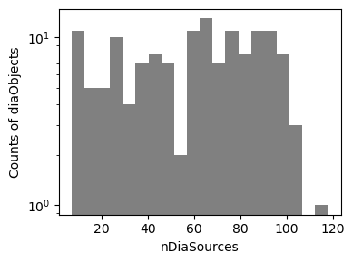

```python
plt.figure(figsize=(4, 3))
plt.hist(results['nDiaSources'], bins=20, log=True, color='gray')
plt.xlabel('nDiaSources')
plt.ylabel('Counts of diaObjects')
plt.tight_layout()
plt.show()
```

> **Figure 1:** Histogram of the number of detections (`nDiaSources`) per `diaObject`.

Plot histograms for a subset of the $r$-band light curve summary statistics.

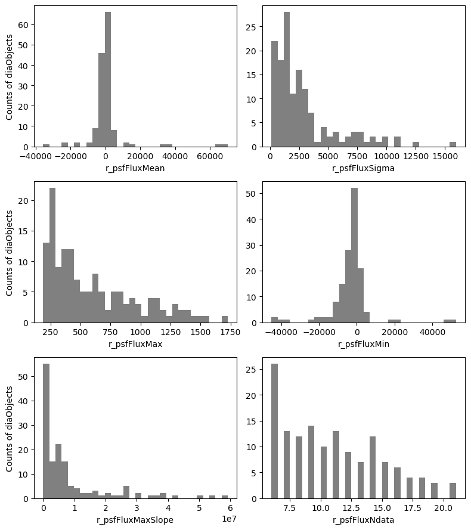

```python
fig, ax = plt.subplots(3, 2, figsize=(8, 9))
axes = ['r_psfFluxMean', 'r_psfFluxSigma',
        'r_psfFluxMax', 'r_psfFluxMin',
        'r_psfFluxMaxSlope', 'r_psfFluxNdata']
a = 0
for i in range(3):
    for j in range(2):
        ax[i, j].hist(results[axes[a]], bins=30, color='gray')
        ax[i, j].set_xlabel(axes[a])
        ax[i, 0].set_ylabel('Counts of diaObjects')
        a += 1
plt.tight_layout()
plt.show()
```

> **Figure 2:** Histograms of the $r$-band light curve summary statistics for the retrieved sample, to show the range of values.

Clean up.

```python
job.delete()
del results
```

### 3.3. Butler

TAP is the recommended way to access the object table, but the butler is a convenient way to retrieve all the objects in a given tract.

Show that the only dimension for the `dia_object` table is the skymap's tract, and that it is required.

```python
butler.get_dataset_type('dia_object')
```

```
DatasetType('dia_object', {skymap, tract}, ArrowAstropy)
```

```python
butler.get_dataset_type('dia_object').dimensions.required
```

```
{skymap, tract}
```

#### 3.3.1. Demo query

**Include spatial constraints:** The butler `dia_object` table contents are stored and retrieved by individual tract.

Retrieve all `dataset_refs` for `dia_object` tables for tracts that overlap the coordinates near the center of the ECDFS field.

```python
query = "tract.region OVERLAPS POINT(53.13, -28.10)"
refs = butler.query_datasets("dia_object", where=query)
```

Show that one tract overlaps the coordinates.

```python
for ref in refs:
    print(ref.dataId)
```

```
{skymap: 'lsst_cells_v2', tract: 5063}
```

Define the columns to retrieve.

```python
col_list = ['diaObjectId', 'ra', 'dec', 'nDiaSources',
            'r_psfFluxMean', 'r_psfFluxMeanErr',
            'r_psfFluxSigma', 'r_psfFluxErrMean',
            'r_psfFluxMax', 'r_psfFluxMin', 'r_psfFluxMaxSlope', 'r_psfFluxNdata']
```

Get the data from the butler, and retrieve it as an `astropy` table.

```python
results = butler.get(refs[0],
                     parameters={'columns': col_list},
                     storageClass='ArrowAstropy')
print(len(results))
```

```
63527
```

Option to display the results.

Notice that because no columns constraints can be applied (e.g., `r_psfFluxNdata` $>5$, as in the TAP query), many values are NAN because there were insufficient detections to derive a flux statistic.

```python
# results
```

Constrain the results to `diaObjects` with more than 5 $r$-band detections.

```python
tx = np.where(results['r_psfFluxNdata'] > 5)[0]
print(len(tx))
```

```
2301
```

To visualize the data, plot the sky coordinates and mean vs. max `r`-band fluxes for the diaObjects in the tract.

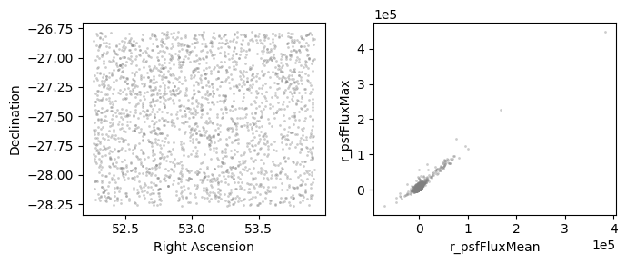

```python
fig, ax = plt.subplots(1, 2, figsize=(7, 3))
ax[0].plot(results['ra'][tx], results['dec'][tx],
           'o', ms=2, mew=0, alpha=0.4, color='grey')
ax[0].set_xlabel('Right Ascension')
ax[0].set_ylabel('Declination')
ax[1].plot(results['r_psfFluxMean'][tx],
           results['r_psfFluxMax'][tx],
           'o', ms=2, mew=0, alpha=0.4, color='grey')
ax[1].set_xlabel('r_psfFluxMean')
ax[1].set_ylabel('r_psfFluxMax')
ax[1].ticklabel_format(axis='both', style='sci', scilimits=(0, 0))
plt.tight_layout()
plt.show()
```

> **Figure 3:** At left, the RA vs. Dec of retrieved objects demonstrates the extent of the tract for which they were retrieved from the Butler. At right, the maximum vs. the mean *r*-band difference-image fluxes are plotted just as an example.

```python
del query, refs, col_list, results, tx
```